# HW2

Author

Jiaqi Zhu

https://github.com/Julie0707/stats506_HW2

## Problem 1 - Dice Game

1. Version 1: Implement this game using a loop over the die rolls.

```r
#' Function to calculate the winnings of the game
#' using a loop
#' @param n a numeric number means the play times
#' @return The total gain or loss
play_dice_v1 <- function(n) {
  total <- -2 * n # for the cost
  for(i in 1:n) {
    roll <- sample(1:6, 1)
    if(roll %% 2 == 0) {
      # Check if even (win)
      total <- total + roll
    }
  }
  return(total)
}
```

Version 2: Implement this game using built-in R vectorized functions.

```r
#' Function to calculate the winnings of the game
#' using built-in R vectorized functions
#' @param n a numeric number means the play times
#' @return The total gain or loss
play_dice_v2 <- function(n) {
  rolls <- sample(1:6, n, replace = TRUE)
  wins <- rolls[rolls %% 2 == 0]
  return(sum(wins) - 2 * n)
}
```

Version 3: Implement this by collapsing the die rolls into a single table()

```r
#' Function to calculate the winnings of the game
#' by collapsing the die rolls into a single table
#' @param n a numeric number means the play times
#' @return The total gain or loss
play_dice_v3 <- function(n) {
  rolls <- sample(1:6, n, replace = TRUE)
  tab <- table(rolls)
  winnings <- sum(as.numeric(names(tab)) * as.integer(tab) * (as.numeric(names(tab)) %% 2 == 0))
  total_cost <- 2 * n
  net_winnings = winnings - total_cost
  return(net_winnings)
}
```

Version 4: Implement this game by using one of the “apply” functions.

```r
#' Function to calculate the winnings of the game
#' using sapply functions
#' @param n a numeric number means the play times
#' @return The total gain or loss
play_dice_v4 <- function(n) {
  rolls <- sample(1:6, n, replace = TRUE)
  results <- sapply(rolls, function(x) if(x %% 2 == 0) return(x) else return(0))
  return(sum(results) - 2 * n)
}
```

2. Demonstrate that all versions work. Do so by running each a few times, once with an input a 3, and once with an input of 3000.
3. Demonstrate that the four versions give the same result. Test with inputs 3 and 3000. (You may need to add a way to control the randomization.)

```r
set.seed(123)
cat("Version 1 results with input 3:", play_dice_v1(3), "\n")
```

```
Version 1 results with input 3: 0
```

```r
set.seed(123)
cat("Version 1 results with input 3000:", play_dice_v1(3000), "\n")
```

```
Version 1 results with input 3000: -102
```

```r
set.seed(123)
cat("Version 2 results with input 3:", play_dice_v2(3), "\n")
```

```
Version 2 results with input 3: 0
```

```r
set.seed(123)
cat("Version 2 results with input 3000:", play_dice_v2(3000), "\n")
```

```
Version 2 results with input 3000: -102
```

```r
set.seed(123)
cat("Version 3 results with input 3:", play_dice_v3(3), "\n")
```

```
Version 3 results with input 3: 0
```

```r
set.seed(123)
cat("Version 3 results with input 3000:", play_dice_v3(3000), "\n")
```

```
Version 3 results with input 3000: -102
```

```r
set.seed(123)
cat("Version 4 results with input 3:", play_dice_v4(3), "\n")
```

```
Version 4 results with input 3: 0
```

```r
set.seed(123)
cat("Version 4 results with input 3000:", play_dice_v4(3000), "\n\n")
```

```
Version 4 results with input 3000: -102
```

4. Use the microbenchmark package to clearly demonstrate the speed of the implementations. Compare performance with a low input (100) and a large input (10000). Discuss the results

```r
library(microbenchmark)
# Benchmark for input = 100
set.seed(123)
micro_100 <- microbenchmark(
  v1 = play_dice_v1(100),
  v2 = play_dice_v2(100),
  v3 = play_dice_v3(100),
  v4 = play_dice_v4(100),
  times = 1000
)

# Benchmark for input = 10000
set.seed(123)
micro_10000 <- microbenchmark(
  v1 = play_dice_v1(10000),
  v2 = play_dice_v2(10000),
  v3 = play_dice_v3(10000),
  v4 = play_dice_v4(10000),
  times = 1000
)
```

```r
print(micro_100)
```

```
Unit: microseconds
 expr     min       lq      mean   median       uq      max neval
   v1 507.626 520.8965 575.06367 527.3760 548.5630 4828.751  1000
   v2  78.042  80.0420  81.46639  80.7920  81.8760  107.334  1000
   v3  78.125  89.7920  97.31836  91.6670  95.2715 2385.501  1000
   v4 150.376 153.4590 164.60992 154.8965 157.3965 3296.417  1000
```

```r
print(micro_10000)
```

```
Unit: microseconds
 expr       min         lq       mean     median        uq       max neval
   v1 53705.750 54946.2505 56402.4585 55610.7920 57358.688 82876.626  1000
   v2  7242.751  7277.9590  7298.3445  7290.4795  7307.501  7565.959  1000
   v3   840.834   874.3965   936.7055   947.1675   985.022  1182.334  1000
   v4 13399.501 13630.8545 14227.6322 13701.7090 14024.292 40759.792  1000
```

The microbenchmark package calculate time and compare the execution speed of R expressions. We can compare multiple versions of a function to see which one is the fastest.

5. Do you think this is a fair game? Defend your decision with evidence based upon a Monte Carlo simulation.

I assume the input variable is a random variable that follows a discrete Uniform distribution, that is to say in each experiment we assume the player play the same times dice game. Now we set this value as 20. If we conduct N experiments, then we repeat it N times, and calculate the Mean of the results eventually. If it’s a fair game, then on average it should have a zero net return. If the final result is pretty close to zero, we consider it fair.

```r
#' Function to calculate the gain or loss of the game over experiments
#' using Monte Carlo simulation
#' @param n a numeric number means the experiment times
#' @return The gain or loss on average
simulate_game <- function(N) {
  results <- numeric(N)
  for(i in 1:N) {
    results[i] <- play_dice_v2(20)
  }
  return(mean(results))
}

N <- 1e6
average_winnings <- simulate_game(N)
print(average_winnings)
```

```
[1] 7e-04
```

As is shown above, the average_winnings is pretty close to zero, so there is no extra winning compared to its cost. I consider it a fair game.

## Problem 2 - Linear Regression

1. The names of the variables in this data are way too long. Rename the columns of the data to more reasonable lengths.

```r
df <- read.csv("/Users/jiaqizhu/Downloads/506/cars.csv",header = TRUE)
names(df) <- c("Height","Length","Width","Driveline","Engine.Type","Hybrid","Forward.Gears","Transmission","City.mpg","Fuel.Type","Highway.mpg","Classification","ID","Make","Model.Year","Year","Horsepower","Torque")
```

2. Restrict the data to cars whose Fuel Type is “Gasoline”.

```r
df_gasoline <- subset(df, Fuel.Type == "Gasoline")
```

3. Fit a linear regression model predicting MPG on the highway.

```r
model <- lm(Highway.mpg ~ Horsepower + Torque + Height + Length + Width + as.factor(Year), data=df_gasoline)
summary(model)
```

```
Call:
lm(formula = Highway.mpg ~ Horsepower + Torque + Height + Length +
    Width + as.factor(Year), data = df_gasoline)

Residuals:
    Min      1Q  Median      3Q     Max
-10.824  -2.550  -0.452   2.372 202.639

Coefficients:
                      Estimate Std. Error t value Pr(>|t|)
(Intercept)         32.2926630  0.7225982  44.690  < 2e-16 ***
Horsepower           0.0163556  0.0022772   7.182 7.96e-13 ***
Torque              -0.0507425  0.0022030 -23.034  < 2e-16 ***
Height               0.0099079  0.0011267   8.794  < 2e-16 ***
Length               0.0017290  0.0008836   1.957   0.0504 .
Width               -0.0003343  0.0009045  -0.370   0.7117
as.factor(Year)2010 -0.4539681  0.6768246  -0.671   0.5024
as.factor(Year)2011  0.1711016  0.6757043   0.253   0.8001
as.factor(Year)2012  1.3029279  0.6810076   1.913   0.0558 .
---
Signif. codes:  0 '***' 0.001 '**' 0.01 '*' 0.05 '.' 0.1 ' ' 1

Residual standard error: 4.602 on 4582 degrees of freedom
Multiple R-squared:  0.4192,    Adjusted R-squared:  0.4182
F-statistic: 413.3 on 8 and 4582 DF,  p-value: < 2.2e-16
```

There is a positive relationship between Horsepower and Highwaympg. The coefficient for Horsepower represents the change in Highway.MPG for a one-unit increase in Horsepower, so if Horsepower increase 1 unit, Highway.MPG will increase 0.016, holding all other control variables constant. And this effect is statistically significant.

4. It seems reasonable that there may be an interaction between horsepower and torque. Refit the model (with lm) and generate an interaction plot, showing how the relationship between horsepower and MPG changes as torque changes. Choose reasonable values of horsepower, and show lines for three different reasonable values of torque.

```r
model_interaction <- lm(Highway.mpg ~ Horsepower*Torque + Height + Length + Width + as.factor(Year), data=df_gasoline)
summary(model_interaction)
```

```
Call:
lm(formula = Highway.mpg ~ Horsepower * Torque + Height + Length +
    Width + as.factor(Year), data = df_gasoline)

Residuals:
    Min      1Q  Median      3Q     Max
-11.109  -2.313  -0.258   2.062 203.540

Coefficients:
                      Estimate Std. Error t value Pr(>|t|)
(Intercept)          4.219e+01  7.930e-01  53.199  < 2e-16 ***
Horsepower          -1.666e-02  2.539e-03  -6.563 5.84e-11 ***
Torque              -8.606e-02  2.533e-03 -33.972  < 2e-16 ***
Height               6.560e-03  1.070e-03   6.133 9.32e-10 ***
Length               1.777e-03  8.318e-04   2.136   0.0327 *
Width               -1.169e-03  8.521e-04  -1.372   0.1700
as.factor(Year)2010 -5.628e-01  6.372e-01  -0.883   0.3771
as.factor(Year)2011  7.254e-02  6.361e-01   0.114   0.9092
as.factor(Year)2012  1.197e+00  6.411e-01   1.867   0.0619 .
Horsepower:Torque    1.124e-04  4.628e-06  24.276  < 2e-16 ***
---
Signif. codes:  0 '***' 0.001 '**' 0.01 '*' 0.05 '.' 0.1 ' ' 1

Residual standard error: 4.333 on 4581 degrees of freedom
Multiple R-squared:  0.4854,    Adjusted R-squared:  0.4844
F-statistic: 480.1 on 9 and 4581 DF,  p-value: < 2.2e-16
```

```r
summary(df_gasoline$Torque)
```

```
   Min. 1st Qu.  Median    Mean 3rd Qu.    Max.
   98.0   177.0   257.0   267.2   332.0   774.0
```

```r
summary(df_gasoline$Horsepower)
```

```
   Min. 1st Qu.  Median    Mean 3rd Qu.    Max.
  100.0   185.0   263.0   267.5   317.0   638.0
```

The reasonable choice for values of torque is its (mean-sd., mean, mean+sd.), and the reasonable range for horsepower is (min., max.) i.e. (100, 630). And the package “interactions” automatically choose that. As for the year, I choose 2012 for prediction since it’s the closest to the present.

```
Using data df_gasoline from global environment. This could cause incorrect
results if df_gasoline has been altered since the model was fit. You can
manually provide the data to the "data =" argument.
```

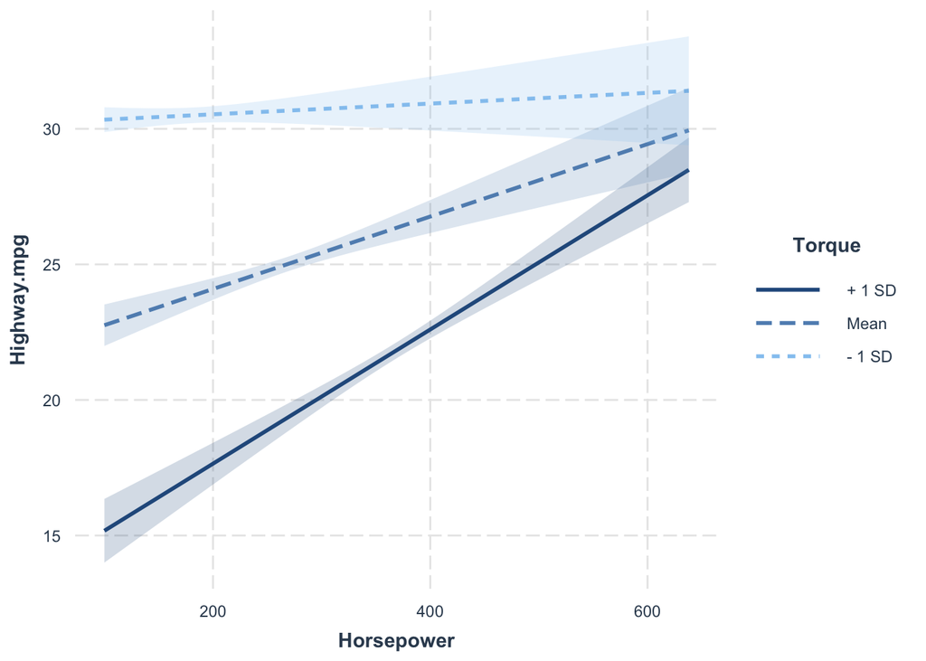

```r
library(interactions)
interact_plot(model_interaction, pred = Horsepower, modx = Torque, interval = TRUE, at = list(Year = 2012))
```

5. Calculate beta from d. manually (without using lm) by first creating a proper design matrix, then using matrix algebra to estimate beta. Confirm that you get the same result as lm did prior.

```r
X <- model.matrix(~ Horsepower*Torque + Height + Length + Width + as.factor(Year), data=df_gasoline)
y <- df_gasoline$Highway.mpg
beta_manual <- solve(t(X) %*% X) %*% t(X) %*% y
beta_lm <- coef(model_interaction)
print(beta_manual)
```

```
                             [,1]
(Intercept)         42.1879478687
Horsepower          -0.0166633227
Torque              -0.0860592704
Height               0.0065603903
Length               0.0017767232
Width               -0.0011694485
as.factor(Year)2010 -0.5627857770
as.factor(Year)2011  0.0725356431
as.factor(Year)2012  1.1970329986
Horsepower:Torque    0.0001123567
```

```r
print(beta_lm)
```

```
        (Intercept)          Horsepower              Torque              Height
      42.1879478687       -0.0166633227       -0.0860592704        0.0065603903
             Length               Width as.factor(Year)2010 as.factor(Year)2011
       0.0017767232       -0.0011694485       -0.5627857770        0.0725356431
as.factor(Year)2012   Horsepower:Torque
       1.1970329986        0.0001123567
```

It’s obvious that the results I get with manual calculation are identical to the prior results.

## Problem 3 - Stata

Repeat problem 2 parts a. through d. in Stata. 1. Import the data

```stata
. capture log close
. clear
. set memory 60000
. set matsize 150
. set more 1
. cd "/Users/jiaqizhu/Downloads/506"
. log using hw1_p3.log, replace
. import delimited "cars.csv"
. describe

Contains data
  obs:         5,076
 vars:            18
 size:     1,543,104
------------------------------------------------------------------------------------
              storage   display    value
variable name   type    format     label      variable label
------------------------------------------------------------------------------------
dimensionshei~t int     %8.0g                 Dimensions.Height
dimensionslen~h int     %8.0g                 Dimensions.Length
dimensionswidth int     %8.0g                 Dimensions.Width
engineinform~ne str17   %17s                  Engine Information.Driveline
engineinform~pe str60   %60s                  Engine Information.Engine Type
engineinform~id str4    %9s                   Engine Information.Hybrid
engineinform~rd byte    %8.0g                 Engine Information.Number of Forward
                                                Gears
engineinforma~n str30   %30s                  Engine Information.Transmission
fuelinfor~tympg byte    %8.0g                 Fuel Information.City mpg
fuelinformati~e str22   %22s                  Fuel Information.Fuel Type
fuelinfor~aympg int     %8.0g                 Fuel Information.Highway mpg
identificatio~n str22   %22s                  Identification.Classification
identificatio~d str67   %67s                  Identification.ID
identificatio~e str18   %18s                  Identification.Make
identific~lyear str48   %48s                  Identification.Model Year
identific~nyear int     %8.0g                 Identification.Year
engineinforma~c int     %8.0g                 Engine Information.Engine
                                                Statistics.Horsepower
v18             int     %8.0g                 Engine Information.Engine
                                                Statistics.Torque
------------------------------------------------------------------------------------
Sorted by:
     Note: Dataset has changed since last saved.
```

2. Rename and Restrict the data

```stata
. rename dimensionsheight height
. rename dimensionslength length
. rename dimensionswidth width
. rename engineinformationdriveline driveline
. rename engineinformationenginetype enginetype
. rename engineinformationhybrid hybrid
. rename engineinformationnumberofforward numberofforward
. rename engineinformationtransmission transmission
. rename fuelinformationcitympg citympg
. rename fuelinformationfueltype fueltype
. rename fuelinformationhighwaympg Highwaympg
. rename identificationclassification classification
. rename identificationid id
. rename identificationmake make
. rename identificationmodelyear modelyear
. rename identificationyear year
. rename engineinformationenginestatistic Horsepower
. rename v18 Torque

. gen gasoline_data = (fueltype == "Gasoline")
. keep if gasoline_data == 1
. describe
```

3. Fitting the Linear Regression Model

```stata
. regress Highwaympg Horsepower Torque height length width i.year

      Source |       SS           df       MS      Number of obs   =     4,591
-------------+----------------------------------   F(8, 4582)      =    413.35
       Model |  70043.6695         8  8755.45869   Prob > F        =    0.0000
    Residual |   97055.298     4,582  21.1818634   R-squared       =    0.4192
-------------+----------------------------------   Adj R-squared   =    0.4182
       Total |  167098.968     4,590  36.4050038   Root MSE        =    4.6024

------------------------------------------------------------------------------
  Highwaympg |      Coef.   Std. Err.      t    P>|t|     [95% Conf. Interval]
-------------+----------------------------------------------------------------
  Horsepower |   .0163556   .0022772     7.18   0.000     .0118913      .02082
      Torque |  -.0507425    .002203   -23.03   0.000    -.0550614   -.0464236
      height |   .0099079   .0011267     8.79   0.000      .007699    .0121168
      length |    .001729   .0008836     1.96   0.050    -3.36e-06    .0034613
       width |  -.0003343   .0009045    -0.37   0.712    -.0021075    .0014388
             |
        year |
       2010  |  -.4539681   .6768246    -0.67   0.502     -1.78087    .8729342
       2011  |   .1711016   .6757043     0.25   0.800    -1.153604    1.495808
       2012  |   1.302928   .6810076     1.91   0.056    -.0321751    2.638031
             |
       _cons |   32.29266   .7225982    44.69   0.000     30.87602     33.7093
------------------------------------------------------------------------------
```

There is a positive relationship between Horsepower and Highwaympg. The coefficient for Horsepower represents the change in Highway.MPG for a one-unit increase in Horsepower, so if Horsepower increase 1 unit, Highway.MPG will increase 0.016, holding all other control variables constant. And this effect is statistically significant at 0.01 level.

4. Fitting Model with Interaction

```stata
. gen hp_torque = Horsepower * Torque
. regress Highwaympg Horsepower Torque hp_torque height length width i.year

      Source |       SS           df       MS      Number of obs   =     4,591
-------------+----------------------------------   F(9, 4581)      =    480.07
       Model |  81105.8715         9  9011.76351   Prob > F        =    0.0000
    Residual |   85993.096     4,581  18.7716865   R-squared       =    0.4854
-------------+----------------------------------   Adj R-squared   =    0.4844
       Total |  167098.968     4,590  36.4050038   Root MSE        =    4.3326

------------------------------------------------------------------------------
  Highwaympg |      Coef.   Std. Err.      t    P>|t|     [95% Conf. Interval]
-------------+----------------------------------------------------------------
  Horsepower |  -.0166633   .0025388    -6.56   0.000    -.0216406    -.011686
      Torque |  -.0860593   .0025333   -33.97   0.000    -.0910257   -.0810928
   hp_torque |   .0001124   4.63e-06    24.28   0.000     .0001033    .0001214
      height |   .0065604   .0010696     6.13   0.000     .0044634    .0086573
      length |   .0017767   .0008318     2.14   0.033     .0001459    .0034075
       width |  -.0011694   .0008521    -1.37   0.170      -.00284    .0005011
             |
        year |
       2010  |  -.5627858   .6371716    -0.88   0.377    -1.811949    .6863777
       2011  |   .0725356   .6361142     0.11   0.909    -1.174555    1.319626
       2012  |   1.197033   .6411085     1.87   0.062    -.0598488    2.453915
             |
       _cons |   42.18795   .7930274    53.20   0.000     40.63323    43.74266
------------------------------------------------------------------------------
```

and it’s equivalent to

```stata
. reg Highwaympg c.Horsepower##c.Torque height length width i.year

      Source |       SS           df       MS      Number of obs   =     4,591
-------------+----------------------------------   F(9, 4581)      =    480.07
       Model |  81105.8715         9  9011.76351   Prob > F        =    0.0000
    Residual |   85993.096     4,581  18.7716865   R-squared       =    0.4854
-------------+----------------------------------   Adj R-squared   =    0.4844
       Total |  167098.968     4,590  36.4050038   Root MSE        =    4.3326

---------------------------------------------------------------------------------------
           Highwaympg |      Coef.   Std. Err.      t    P>|t|     [95% Conf. Interval]
----------------------+----------------------------------------------------------------
           Horsepower |  -.0166633   .0025388    -6.56   0.000    -.0216406    -.011686
               Torque |  -.0860593   .0025333   -33.97   0.000    -.0910257   -.0810928
                      |
c.Horsepower#c.Torque |   .0001124   4.63e-06    24.28   0.000     .0001033    .0001214
                      |
               height |   .0065604   .0010696     6.13   0.000     .0044634    .0086573
               length |   .0017767   .0008318     2.14   0.033     .0001459    .0034075
                width |  -.0011694   .0008521    -1.37   0.170      -.00284    .0005011
                      |
                 year |
                2010  |  -.5627858   .6371716    -0.88   0.377    -1.811949    .6863777
                2011  |   .0725356   .6361142     0.11   0.909    -1.174555    1.319626
                2012  |   1.197033   .6411085     1.87   0.062    -.0598488    2.453915
                      |
                _cons |   42.18795   .7930274    53.20   0.000     40.63323    43.74266
---------------------------------------------------------------------------------------
```

As is shown above, the interaction term is significant at 0.01 level. So there is indeed a interaction effect between horsepower and torque.

5. Generating an Interaction Plot:

```stata
. tabstat Torque, stat(count mean sd p25 p50 p75 min max)

    variable |         N      mean        sd       p25       p50       p75       min       max
-------------+--------------------------------------------------------------------------------
      Torque |      4591  267.2196  101.3269       177       257       332        98       774
----------------------------------------------------------------------------------------------

. tabstat Horsepower, stat(count mean sd p25 p50 p75 min max)

    variable |         N      mean        sd       p25       p50       p75       min       max
-------------+--------------------------------------------------------------------------------
  Horsepower |      4591  267.4659  97.43199       185       263       317       100       638
----------------------------------------------------------------------------------------------
```

The reasonable choice for values of torque is its (1st qu., median, and 3rd qu.), being 177, 257, and 332 resp. And the reasonable range for horsepower is (100, 630).

```stata
. margins, at(Horsepower=(100(50)638) Torque=(177 257 332))
. marginsplot, noci recast(line) ///
>     scheme(s1color) ///
>     legend(on) ///
>     name(MarginsPlot, replace) ///
>     title("Interaction between Horsepower and Torque on Highwaympg") ///
>     ytitle("Predicted Highwaympg") xtitle("Horsepower") ///
>     xlabel(100(50)638) ylabel(, nogrid) ///
>

  Variables that uniquely identify margins: Horsepower Torque
```

The plot we get this time is similar to the R-generated one.

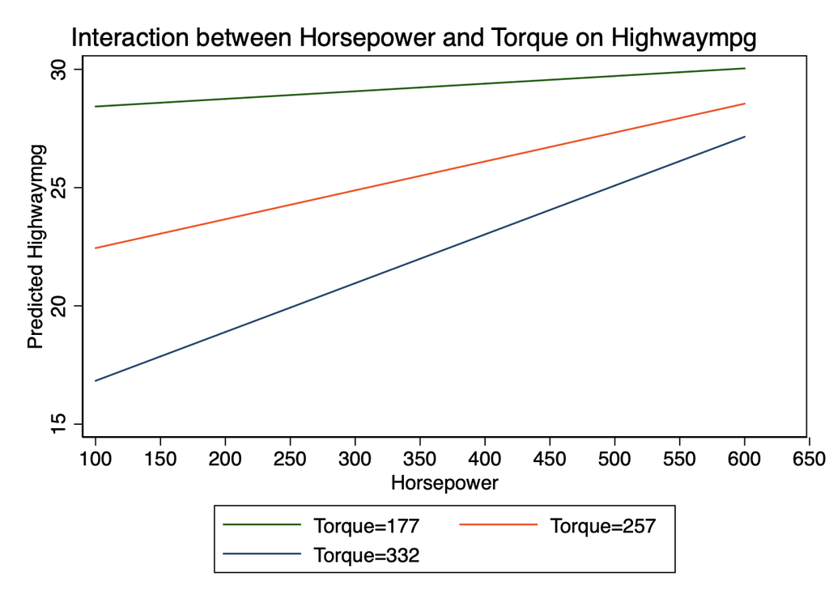